# HOmics: Hierarchical modelling for omics data analyses

Lara Nonell and Juan R Gonzalez

Institut Hospital del Mar d'Investigacions Mediques - IMIM  
Bioinformatics Research Group in Epidemiology, Barcelona Institute for Global Health, Spain

juanr.gonzalez@isglobal.org

August, 2019

# 1 Introduction

**HOmics** package is designed to analyze *omics* data by incorporating biological knowledge aiming to improve effect estimates obtained from single association analyses. Instead of assuming that every *omic* feature is a priori equally likely associated with the outcome of interest, one can quantitatively incorporate existing information about the features into the analysis. The ultimate goal of this approach is to obtain a better rank of features by combining both, the effect estimates from the data and a priori biological knowledge. The data are fitted in a two levels hierarchical model, where the first level is a regression model for the features, whose coefficients are adjusted in a second level using prior information.

**HOmics** uses a Bayesian approach that needs the JAGS (Just Another Gibbs Sampler) environment to be installed. This can be easily done through this link: http://mcmc-jags.sourceforge.net/.

To install the package use the following commands:

- Windows

```r
library(devtools)
install_github("isglobal-brge/HOmics", INSTALL_opts=c("--no-multiarch"))
```

- Linux

```r
library(devtools)
install_github("isglobal-brge/HOmics")
```

We illustrate the method with five examples: 1) SNP association studies, where information about genic annotations can be incorporated in the analyses in a univariate or 2) multivariate manner, 3) epigenomic gene studies where relative position to the closest gene is incorporated for each CpG using bioconductor’s standard classes, 4) gene expression association to ovarian cancer including information about the predicted miRNAs and 5) integration of gene expression with methylation data in the association to phenotype.

The general idea is described in the following figure:

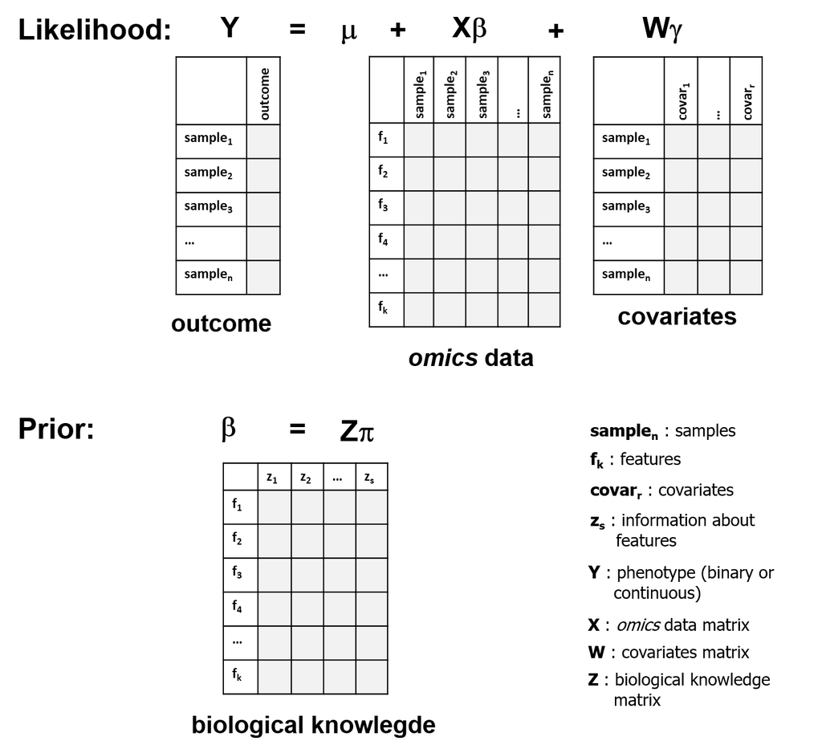

Figure 1: Hierarchical model  
Levels and components of the HOmics hierarchical model.

```r
library(HOmics)
library(dplyr)
```

# 2 Incorporating prior knowledge

## 2.1 Example 1: SNP association analyses

In the GWAS conext, each SNP is associated independently with the phenotype of interest. However, this conventional approach ignores existing information about the analyzed SNPs and assumes that they are all equally likely to impact the phenotype. Instead, one can incorporate information about the SNPs into a hierarchical model, in an attempt to improve the ranking of the p-values for association. There are several ways of incorporating a priori information. For instance, one can weight each SNP association p-value by how well it tags to SNPs that have been previously associated with our phenotype of interest as described in the GWAS catalog (https://www.ebi.ac.uk/gwas/). The genetic distance to these SNPs can also be used. Another option is to incorporate existing information about the SNPs into a second-stage design matrix Z. This information could be: conservation, functional category, gene location, tagging or even linkage. Here we illustrate how genic location depicted in this figure can be used to improve single SNP assocation analyses:

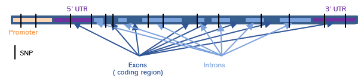

Figure 2: Genic annotation  
Components of the gene with the SNP positions relative to the exonic and intronic gene composition.

Let us illustrate how to do the analyses with the first example, using a real data set on obesity. We have genotypes for a total of 73 SNPs measured in 300 idividuals. Data can be loaded directly from the package by

```r
data("obesity", package="HOmics")
```

We have two different objects, one for the genotypes and another for the phenotypic variables. Notice that the rownames of both objects perfectly match:

```r
snps[1:6, 1:5]
```

```
     rs12921005 rs1420537 rs4784212 rs9925256 rs1420546
4180          1         2         2         1         1
4938          2         0         2         2         1
2405          1         2         0         2         2
323           2         2         2         0         2
4193          2         1         2         1         1
920           0         1         2         1         1
```

```r
head(ob)
```

```
     gender obese age   smoke country
4180   Male     1  41 Current      50
4938   Male     0  44 Current      53
2405   Male     1  46 Current      55
323  Female     0  43 Current      53
4193 Female     0  49      Ex      53
920    Male     1  54 Current      50
```

```r
identical(rownames(ob), rownames(snps))
```

```
[1] TRUE
```

Now the idea is to associate each SNP with the obesity status (0: normal, 1: obese) by incorporating information about the gene position of each SNP as described in the previous figure.

```r
rsids <- colnames(snps)
head(rsids)
```

```
[1] "rs12921005" "rs1420537"  "rs4784212"  "rs9925256"  "rs1420546"
[6] "rs9302555"
```

```r
length(rsids)
```

```
[1] 73
```

One can locate SNPs in and around genes by using some Bioconductor’s packages as follows:

```r
library(GenomicRanges)
library(VariantAnnotation)
library(TxDb.Hsapiens.UCSC.hg19.knownGene)
library(SNPlocs.Hsapiens.dbSNP144.GRCh37)

txdb <- TxDb.Hsapiens.UCSC.hg19.knownGene
snps.annot <- SNPlocs.Hsapiens.dbSNP144.GRCh37

snpPos <- snpsById(snps.annot, rsids)
snps.loc <- GRanges(seqnames = seqnames(snpPos),
                    IRanges(start=start(snpPos),
                            end=end(snpPos)),
                    rs=snpPos$RefSNP_id)

seqlevelsStyle(snps.loc) <- seqlevelsStyle(txdb)
genome(snps.loc) <- genome(txdb)

loc <- locateVariants(snps.loc, txdb,  AllVariants())
loc <- merge(loc, snps.loc, all.x=TRUE)
m <- findOverlaps(snps.loc, loc)
mcols(loc)[subjectHits(m), "rs"] <-
  mcols(snps.loc)[queryHits(m), "rs"]
loc.unique <- unique(loc)
```

This is the information we have after being processed the previous chunk, a GRanges object:

```r
loc.unique[,c("LOCATION","rs")]
```

```
GRanges object with 74 ranges and 2 metadata columns:
       seqnames    ranges strand |   LOCATION          rs
          <Rle> <IRanges>  <Rle> |   <factor> <character>
   [1]    chr16  53125819      + |     intron   rs1108574
   [2]    chr16  53191470      + |     intron  rs12597487
   [3]    chr16  53197934      + |     intron   rs1421069
   [4]    chr16  53238253      + |     intron  rs10521279
   [5]    chr16  53283668      + |     intron   rs8058067
   ...      ...       ...    ... .        ...         ...
  [70]    chr16  54367420      * | intergenic   rs4783835
  [71]    chr16  54396362      * | intergenic   rs4784375
  [72]    chr16  54407804      * | intergenic    rs748815
  [73]    chr16  54414443      * | intergenic  rs12931564
  [74]    chr16  54415702      * | intergenic  rs11639567
  -------
  seqinfo: 25 sequences from hg19 genome; no seqlengths
```

Then the Z matrix providing a priori biological knowledge can be created using the following code. Notice that: 1) some SNPs may not be annotated; and 2) a given SNP may have 1 or more than one relative positions. This is addressed by adding Z matrix by the rownames. Notice that SNPs rs2908786 and rs3743772 are in two gene relative locations:

```r
location <- droplevels(loc.unique$LOCATION)
Z <- model.matrix(~ 0 + location)
colnames(Z) <- levels(location)
rownames(Z) <- loc.unique$rs

Z <- t(sapply(by(Z,rownames(Z),colSums),identity))
dim(Z)
```

```
[1] 72  5
```

```r
head(Z)
```

```
           intron threeUTR coding intergenic promoter
rs1004299       0        0      0          1        0
rs1013170       0        0      0          1        0
rs10521279      1        0      0          0        0
rs10521294      0        0      0          1        0
rs1108574       1        0      0          0        0
rs1112899       0        0      0          1        0
```

```r
head(sort(apply(Z,1,sum), decreasing = TRUE))
```

```
 rs2908786  rs3743772  rs1004299  rs1013170 rs10521279 rs10521294
         2          2          1          1          1          1
```

Next code illustrates how to fit the hierachical model. We start by selecting from the omic matrix those features with annotated information.

```r
rsids.ok <- rownames(Z)
omic.matrix <- as.matrix(t(snps[, rsids.ok]))
```

Then we create the W matrix which includes the covariates:

```r
covar.matrix <- model.matrix( ~ gender + age, data=ob)
```

Finally the model is fitted by:

```r
mod <- HOmics(data.matrix = omic.matrix,
              cond = as.factor(ob$obese),
              z.matrix = Z,
              covar.matrix = covar.matrix)
```

```
univariate analysis will be performed for each feature
cond is a factor, it has been converted to a numerical vector of 0s and 1s with 0 as the reference level. A hierarchical logistic model will be fitted
```

The results are provided as an object of class *HOmics* with several attributes.

```r
mod
```

```
Object of class HOmics
A hierarchical univariate model was fitted for each feature

Call:
HOmics(data.matrix = omic.matrix, cond = as.factor(ob$obese),
    z.matrix = Z, covar.matrix = covar.matrix)
```

```r
attributes(mod)
```

```
$names
[1] "results" "call"    "univ"    "cont"

$class
[1] "HOmics"
```

Results can be extracted using the attribute results.

```r
mod$results
```

```
[[1]]
# A tibble: 72 x 9
   feature     mean `2.5%` `50%` `97.5%`  Rhat n.eff  p.pos p.neg
   <chr>      <dbl>  <dbl> <dbl>   <dbl> <dbl> <dbl>  <dbl> <dbl>
 1 rs1004299  -0.03  -0.43 -0.03    0.35  1.01   844 0.440  0.560
 2 rs1013170  -0.04  -0.59 -0.04    0.51  1.02   226 0.446  0.554
 3 rs10521279 -0.1   -0.53 -0.1     0.31  1      595 0.319  0.681
 4 rs10521294  0.37  -0.34  0.36    1.1   1.02   116 0.843  0.157
 5 rs1108574  -0.02  -0.43 -0.01    0.38  1      629 0.470  0.530
 6 rs1112899  -0.19  -0.76 -0.19    0.37  1      189 0.265  0.735
 7 rs1125338  -0.22  -0.62 -0.22    0.2   1      843 0.141  0.859
 8 rs11639567 -0.43  -0.83 -0.42   -0.04  1     1037 0.0128 0.987
 9 rs11642776  0.03  -0.78  0.02    0.93  1.03    75 0.512  0.488
10 rs11859998  0.19  -0.61  0.15    1.08  1.02    74 0.644  0.356
# ... with 62 more rows
```

which is a list of tibbles.

To visualize credible intervals:

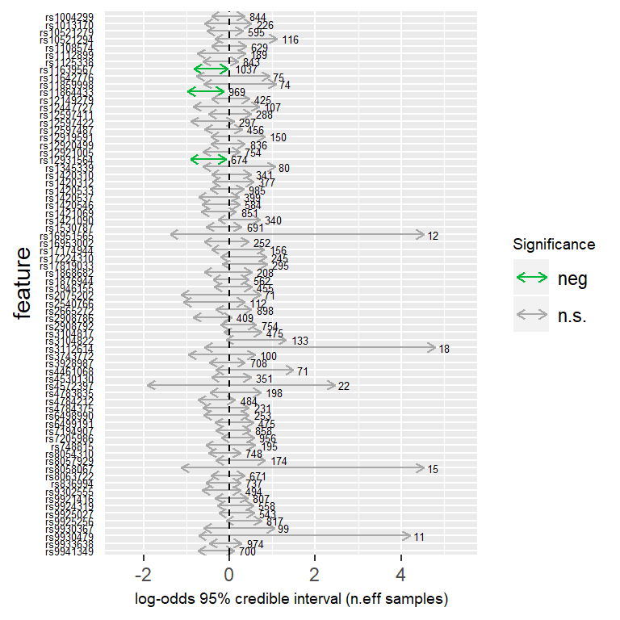

Figure 3: HOmics coefficients  
Credible intervals for the assessed SNPs obtained with HOmics.

```r
plot(mod)
```

We then can compare these results with the results obtained from standard association analyses using SNPassoc package.

```r
library(SNPassoc)
dd <- cbind(snps, ob)
ii <- grep("^rs", colnames(dd))
dd.s <- setupSNP(dd, colSNPs = ii,
                 name.genotypes = c(0,1,2))
ans <- WGassociation(obese, dd.s, model="log")
head(ans)
```

```
           comments log-additive
rs12921005        -      0.44593
rs1420537         -      0.51014
rs4784212         -      0.11534
rs9925256         -      0.11757
rs1420546         -      0.66599
rs9302555         -      0.34211
```

```r
ans.odds <- odds(ans)
```

if we now plot SNPassoc log-odds confidence interval

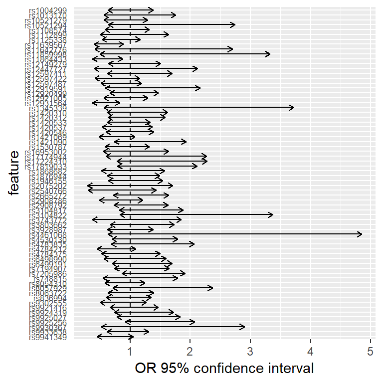

Figure 4: SNPassoc coefficients  
Confidence intervals for the assessed SNPs obtained with SNPassoc.

And finally compare results, by selecting those significative results by each method and transforming SNPassoc results to log-odds. Notice that objects are manipulated differently, as they are of different classes:

```r
res.homics <- mod$results[[1]]
res.homics.sig <- res.homics %>%
                  filter(sign(`97.5%`) ==  sign(`2.5%`), n.eff>200) %>%
                  mutate(int.l =`97.5%`- `2.5%`)
res.homics.sig
```

```
# A tibble: 3 x 10
  feature     mean `2.5%` `50%` `97.5%`  Rhat n.eff  p.pos p.neg int.l
  <chr>      <dbl>  <dbl> <dbl>   <dbl> <dbl> <dbl>  <dbl> <dbl> <dbl>
1 rs11639567 -0.43  -0.83 -0.42   -0.04     1  1037 0.0128 0.987 0.790
2 rs11864433 -0.56  -0.99 -0.56   -0.14     1   969 0.0038 0.996 0.85
3 rs12931564 -0.51  -0.92 -0.51   -0.09     1   674 0.01   0.99  0.83
```

```r
res.snpassoc <- ans.odds
res.snpassoc.sig <- res.snpassoc[res.snpassoc$`p-value.log-additive`<0.05 &
                                  !is.na(res.snpassoc$`p-value.log-additive`),]

res.snpassoc.sig$log.odds <- log(res.snpassoc.sig$OR)
res.snpassoc.sig$log.lower <- log(res.snpassoc.sig$lower)
res.snpassoc.sig$log.upper <- log(res.snpassoc.sig$upper)

res.snpassoc.sig$int.l <- res.snpassoc.sig$log.upper - res.snpassoc.sig$log.lower

res.snpassoc.sig[,c("log.odds","log.lower","log.upper")]
```

```
             log.odds  log.lower  log.upper
rs11864433 -0.5621189 -0.9942523 -0.1278334
rs12931564 -0.5798185 -0.9942523 -0.1863296
rs11639567 -0.5108256 -0.9162907 -0.1165338
```

Observe that significative SNPs associated to obesity are the same but the credible intervals (equivalent to confidence intervals) for **HOmics** approach have changed after including prior information.

## 2.2 Example 2: Multivariate SNP association analysis

Instead of performing a univariate analysis for each feature, we can include all SNPs in a multivariate model to study the association with phenotype. For that, the parameter agg.matrix must be specified with groups of features as depicted in the following figure:

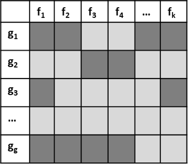

Figure 5: aggregation matrix  
aggregation.matrix, where gi represents the group i and fi the feature i. For each feature fi in group gi, dark grey indicates belonging (1 in the matrix) and pale grey indicates non belonging (0 in the matrix).

```r
agg.matrix <- matrix(data=1,nrow=1,ncol=nrow(omic.matrix))

rownames(agg.matrix) <-"g1"
colnames(agg.matrix) <- rownames(omic.matrix)

mod.multiv <- HOmics(data.matrix = omic.matrix,
              cond = as.factor(ob$obese),
              z.matrix = Z,
              covar.matrix = covar.matrix,
              agg.matrix = agg.matrix)
```

```
cond is a factor, it has been converted to a numerical vector of 0s and 1s with 0 as the reference level. A hierarchical logistic model will be fitted
```

```r
mod.multiv
```

```
Object of class HOmics
A hierarchical multivariate model was fitted for each group

Call:
HOmics(data.matrix = omic.matrix, cond = as.factor(ob$obese),
    z.matrix = Z, covar.matrix = covar.matrix, agg.matrix = agg.matrix)
```

If we want to assess more groups, it should be specified in the aggregation matrix, with each group as a row.

The results are again provided as an *HOmics* object, and results show this time the coefficients for the multivariate model

```r
mod.multiv$results
```

```
$g1
# A tibble: 72 x 9
   feature     mean `2.5%` `50%` `97.5%`  Rhat n.eff p.pos p.neg
   <chr>      <dbl>  <dbl> <dbl>   <dbl> <dbl> <dbl> <dbl> <dbl>
 1 rs1004299   0.09  -0.36  0.09   0.54   1      668 0.663 0.337
 2 rs1013170  -0.01  -0.52 -0.02   0.49   1.03   316 0.477 0.523
 3 rs10521279  0.1   -0.44  0.1    0.64   1      363 0.644 0.356
 4 rs10521294  0.07  -0.48  0.07   0.67   1      231 0.613 0.387
 5 rs1108574   0.12  -0.3   0.12   0.55   1      664 0.714 0.286
 6 rs1112899  -0.17  -0.77 -0.17   0.39   1.03   205 0.278 0.722
 7 rs1125338  -0.26  -0.69 -0.26   0.13   1.01   822 0.106 0.894
 8 rs11639567 -0.25  -0.76 -0.25   0.24   1      507 0.159 0.841
 9 rs11642776  0.01  -0.63  0.02   0.63   1.03   181 0.522 0.478
10 rs11859998 -0.03  -0.63 -0.05   0.580  1.01   186 0.436 0.564
# ... with 62 more rows
```

And we plot the coefficients of the multivariate model to visualize credible intervals

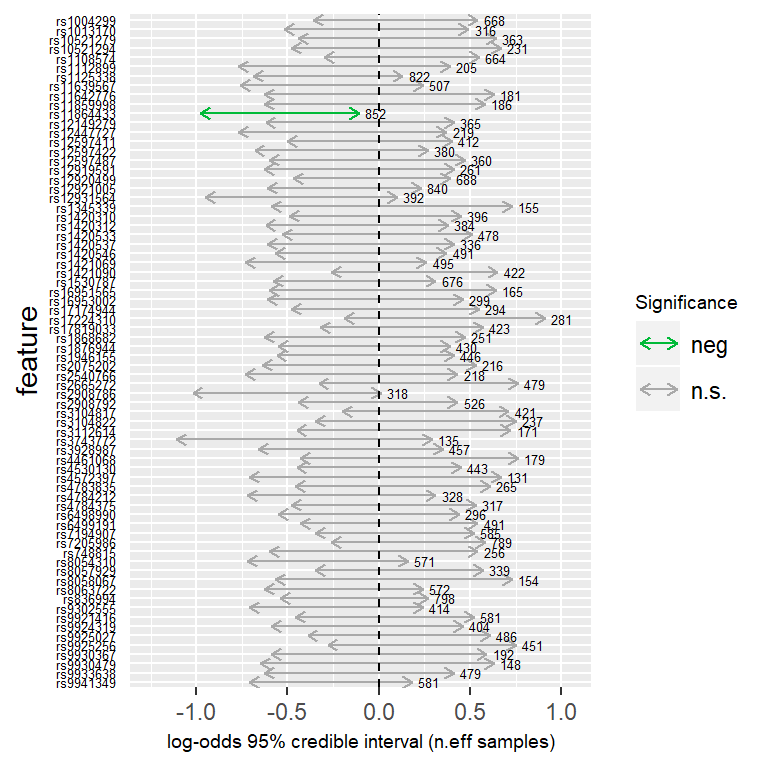

Figure 6: HOmics coefficients in the multivariate model  
Credible intervals for the assessed SNPs obtained with HOmics in the multivariate model.

```r
plot(mod.multiv)
```

## 2.3 Example 3: CpG methylation analyses using bioconductor’s classes

In methylomics, CpGs are studied individually in their association to phenotype. However, there is some information that can be added to the model such as their relative position to the gene. We could here perform a similar analysis to the one displayed in previous section but **HOmics** contains a specific function, **HOmics.meth()** that takes advantage of standard Bioconductor classes. The function is prepared to process ExpressionSet (Biobase) or GenomicRatioSet (minfi), standard classes when downloading GEO data using the GEOquery package. These objects have the following components:

- pheno data: information about the variables to analyze including phenotype and covariates
- annotation data: information about features (featureData for an ExpressionSet)

The relative position of a CpG to the closest gene is in this case the prior information and it is directly extracted from the annotation data of the object.

We will in this example assess an ExpressionSet, extracted from the GEO series GSE117929. Data was previously downloaded using package *GEOquery* and is accessible as the data object *GSE117929* in **HOmics**. *Biobase* package is needed to manipulate ExpressionSet class objects.

GSE117929 contains a methylome-wide analysis of 37 samples of peripheral blood mononuclear cells of systemic sclerosis patients (SSc, N=18) and normal controls (NC, N=19).

```r
library(Biobase)

data("GSE117929", package="HOmics")

GSE117929
```

```
ExpressionSet (storageMode: lockedEnvironment)
assayData: 312028 features, 37 samples
  element names: exprs
protocolData: none
phenoData
  sampleNames: GSM3315436 GSM3315437 ... GSM3315472 (37 total)
  varLabels: title geo_accession ... gender:ch1 (37 total)
  varMetadata: labelDescription
featureData
  featureNames: cg00000029 cg00000108 ... cg17014186 (312028 total)
  fvarLabels: ID Name ... SPOT_ID (37 total)
  fvarMetadata: Column Description labelDescription
experimentData: use 'experimentData(object)'
Annotation: GPL13534
```

```r
table(pData(GSE117929)$"diagnosis:ch1")
```

```
 NC SSc
 19  18
```

The list of genes to model are obtained from [PMC5988798](https://www.nature.com/articles/s41598-018-26894-4), and we just call the function

```r
genes <- c("CCR5","CXCR4")

mod.meth <- HOmics.meth(meth.data = GSE117929,
                   pheno.cond.col = "diagnosis:ch1",
                   annot.gene.col = "UCSC_RefGene_Name",
                   annot.z.col = "UCSC_RefGene_Group",
                   annot.mult.sep = ";",
                   gene.list = genes,
                   cores = 1)
```

```
some missing values were detected, only complete features will be selected
diagnosis:ch1 is a factor, it has been converted to a numerical vector of 0s and 1s with NC as the reference level. A hierarchical logistic model will be fitted
```

```r
mod.meth
```

```
Object of class HOmics
A hierarchical multivariate model was fitted for each group

Call:
HOmics.meth(meth.data = GSE117929, pheno.cond.col = "diagnosis:ch1",
    annot.gene.col = "UCSC_RefGene_Name", annot.z.col = "UCSC_RefGene_Group",
    annot.mult.sep = ";", gene.list = genes, cores = 1)
```

Let us see the results:

```r
mod.meth$results[[1]]
```

```
# A tibble: 4 x 9
  feature     mean `2.5%` `50%` `97.5%`  Rhat n.eff p.pos  p.neg
  <chr>      <dbl>  <dbl> <dbl>   <dbl> <dbl> <dbl> <dbl>  <dbl>
1 cg00803692 20.4    3.11 14.1     48.1  2.87    20 0.996 0.0037
2 cg04131610 -3.63 -32.1  -0.42    17.9  2.52    17 0.489 0.511
3 cg07616471 14.0   -1.6  11.7     36.3  2.36    21 0.966 0.0337
4 cg15239694  4.19  -5.14  4.16    14.3  1.47    42 0.807 0.193
```

We filter the results of those CpGs in genes with high probability of positive coefficients (betas) and also of negative coefficients in the adjusted Bayesian hierarchical model. In this example we filter at a significance level of 0.8 for demo purposes.

```r
res.f.pos <- filter(mod.meth, param = "p.pos", threshold = 0.8, as.data.frame = T)
```

```
notice that this is a probability, so values above threshold will be selected
```

```r
res.f.pos
```

```
# A tibble: 3 x 10
  group feature     mean `2.5%` `50%` `97.5%`  Rhat n.eff p.pos  p.neg
  <chr> <chr>      <dbl>  <dbl> <dbl>   <dbl> <dbl> <dbl> <dbl>  <dbl>
1 CCR5  cg00803692 20.4    3.11 14.1     48.1  2.87    20 0.996 0.0037
2 CCR5  cg07616471 14.0   -1.6  11.7     36.3  2.36    21 0.966 0.0337
3 CCR5  cg15239694  4.19  -5.14  4.16    14.3  1.47    42 0.807 0.193
```

```r
res.f.neg <- filter(mod.meth, param = "p.neg", threshold = 0.8, as.data.frame = T)
```

```
notice that this is a probability, so values above threshold will be selected
```

```r
res.f.neg
```

```
# A tibble: 1 x 10
  group feature     mean `2.5%` `50%` `97.5%`  Rhat n.eff p.pos p.neg
  <chr> <chr>      <dbl>  <dbl> <dbl>   <dbl> <dbl> <dbl> <dbl> <dbl>
1 CXCR4 cg12595667 -8.39  -28.0 -5.19    0.83   1.2    31   0.1   0.9
```

We finally plot 95% credible interval and use method signif to obtain significant results, ie those features with credible intervals not containing 0

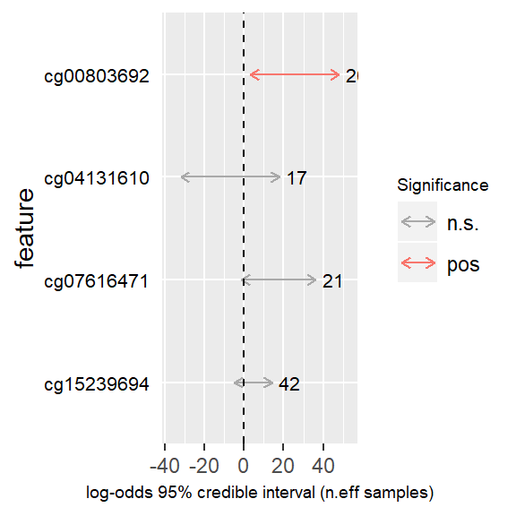

Figure 7: HOmics coefficients  
Credible intervals for the assessed CpGs obtained with HOmics.

```r
plot(mod.meth)
```

```r
signif(mod.meth)
```

```
# A tibble: 1 x 10
  group feature     mean `2.5%` `50%` `97.5%`  Rhat n.eff p.pos  p.neg
  <chr> <chr>      <dbl>  <dbl> <dbl>   <dbl> <dbl> <dbl> <dbl>  <dbl>
1 CCR5  cg00803692  20.4   3.11  14.1    48.1  2.87    20 0.996 0.0037
```

We will now adjust the model by sex variable, which is specified in phenoData as ‘gender:ch1’

```r
genes <- c("CCR5","CXCR4")

mod.meth.sex <- HOmics.meth(meth.data = GSE117929,
                   pheno.cond.col = "diagnosis:ch1",
                   annot.gene.col = "UCSC_RefGene_Name",
                   annot.z.col = "UCSC_RefGene_Group",
                   annot.mult.sep = ";",
                   pheno.covar.col = "gender:ch1",
                   gene.list = genes,
                   cores = 1)
```

```
some missing values were detected, only complete features will be selected
diagnosis:ch1 is a factor, it has been converted to a numerical vector of 0s and 1s with NC as the reference level. A hierarchical logistic model will be fitted
covariate gender:ch1 has been converted to a numerical vector
```

```r
class(mod.meth.sex)
```

```
[1] "HOmics"
```

And we filter adjusted results

```r
res.meth.f.sex.pos <- filter(mod.meth.sex)
```

```
notice that this is a probability, so values above threshold will be selected
```

```r
res.meth.f.sex.pos
```

```
# A tibble: 0 x 0
```

```r
res.meth.f.sex.neg <- filter(mod.meth.sex, param="p.neg")
```

```
notice that this is a probability, so values above threshold will be selected
```

```r
res.meth.f.sex.neg
```

```
# A tibble: 0 x 0
```

## 2.4 Example 4: Ovarian cancer gene expression with targeted miRNAs

Gene expression can be modulated by the miRNAs, that bind to genes during transcription. We will see how this binding can affect the association with phenotype. For this example we will work with data from three different sources:

- ExpressionSet obtained from bicoconductor’s package *curatedovarianData*
- Genes related to ovarian cancer obtained from [The human protein atlas, ovarian cancer](https://www.proteinatlas.org/humanproteome/pathology/ovarian+cancer) and available as a data object in **HOmics**
- Prior information of target miRNA downloaded from TargetScan website (v 7.2 http://www.targetscan.org/vert_72/) and available as a data object in **HOmics**

We will assess the gene expression association with ovarian cancer by fitting a hierarchical model where prior information known about genes are their predicted miRNAs.

```r
# BiocManager::install("curatedOvarianData")

library(curatedOvarianData)
data(TCGA_eset)
TCGA_eset
```

```
ExpressionSet (storageMode: lockedEnvironment)
assayData: 13104 features, 578 samples
  element names: exprs
protocolData: none
phenoData
  sampleNames: TCGA.20.0987 TCGA.23.1031 ... TCGA.13.1819 (578
    total)
  varLabels: alt_sample_name unique_patient_ID ...
    uncurated_author_metadata (31 total)
  varMetadata: labelDescription
featureData
  featureNames: A1CF A2M ... ZZZ3 (13104 total)
  fvarLabels: probeset gene
  fvarMetadata: labelDescription
experimentData: use 'experimentData(object)'
  pubMedIds: 21720365
Annotation: hthgu133a
```

Notice that TCGA_eset is an object of class ExpressionSet. We will compare ovarian cancer tumor samples in stage 4 with recurrence versus healthy samples. From the original TCGA_eset object, we will extract the expression data and the phenotype variables as follows

```r
pheno <- pData(TCGA_eset)
table(pheno$sample_type)
```

```
healthy   tumor
      8     570
```

```r
TCGA_subset <- TCGA_eset[,pheno$sample_type=="healthy" |
                           (pheno$sample_type=="tumor" &
                              pheno$tumorstage==4 &
                              pheno$recurrence_status=="recurrence")]

expr.m <- exprs(TCGA_subset)
dim(expr.m)
```

```
[1] 13104    47
```

```r
pheno <- pData(TCGA_subset)
```

Let us obtain the condition vector

```r
cond <- pheno$sample_type
table(cond)
```

```
cond
healthy   tumor
      8      39
```

The prior matrix with miRNAs that target our set of genes is obtained from the downloaded information obtained at TargetScan

```r
data("targets.hs.7.2", package="HOmics")

targets
```

```
# A tibble: 718,233 x 11
   `miR Family` `Gene ID` `Gene Symbol` `Transcript ID` `Species ID`
   <chr>        <chr>     <chr>         <chr>                  <dbl>
 1 miR-23-3p    ENSG0000~ A1BG          ENST0000026310~         9606
 2 miR-23       ENSG0000~ A1BG          ENST0000026310~         9598
 3 miR-23-3p    ENSG0000~ A1BG          ENST0000026310~         9544
 4 miR-23       ENSG0000~ A1BG          ENST0000026310~         9615
 5 miR-302-3p/~ ENSG0000~ A1CF          ENST0000037400~         9544
 6 miR-302c-3p~ ENSG0000~ A1CF          ENST0000037400~         9606
 7 miR-520      ENSG0000~ A1CF          ENST0000037400~         9598
 8 miR-15/16/1~ ENSG0000~ A1CF          ENST0000037400~         9913
 9 miR-15/16/1~ ENSG0000~ A1CF          ENST0000037400~         9615
10 miR-153      ENSG0000~ A1CF          ENST0000037400~         9598
# ... with 718,223 more rows, and 6 more variables: `UTR start` <dbl>, `UTR
#   end` <dbl>, `MSA start` <dbl>, `MSA end` <dbl>, `Seed match` <chr>,
#   PCT <chr>
```

Let us filter the targets to get only those with probability of conserved targeting (P<sub>CT</sub>) > 0.5 and generate the prior information matrix

```r
targets.f <- targets %>% mutate(PCT= as.numeric(PCT)) %>% filter(PCT >0.5)

z.table <- table(targets.f$`Gene Symbol`, targets.f$`miR Family`)

z.matrix <- as.matrix(as.data.frame.matrix(z.table))

z.matrix[z.matrix>1]<-1

table(z.matrix) # 0s and 1s only
```

```
z.matrix
      0       1
1714767  118666
```

Ovarian specific related genes are stored in a data object

```r
data("ov.genes", package="HOmics")

head(ov.genes$Gene)
```

```
[1] "PDCL2"   "DEFB126" "RBPJL"   "OVGP1"   "COX8C"   "IMPG2"
```

To make sure that features (in this case genes) in the three data sets are the same, we do:

```r
common.genes <- intersect(intersect(rownames(expr.m), ov.genes$Gene),
                          rownames(z.matrix))
length(common.genes)
```

```
[1] 24
```

```r
expr.m <- expr.m[common.genes,]
z.matrix <- z.matrix[common.genes,]

mod.ov <- HOmics(data.matrix = expr.m,
              cond = cond,
              z.matrix = z.matrix)
```

```
univariate analysis will be performed for each feature
cond is a factor, it has been converted to a numerical vector of 0s and 1s with healthy as the reference level. A hierarchical logistic model will be fitted
```

```r
mod.ov$results[[1]]
```

```
# A tibble: 24 x 9
   feature  mean `2.5%` `50%` `97.5%`  Rhat n.eff  p.pos    p.neg
   <chr>   <dbl>  <dbl> <dbl>   <dbl> <dbl> <dbl>  <dbl>    <dbl>
 1 ALK      3.13   0.91  2.99   5.45   1.09    27 1      0
 2 CDH6     0.74   0.16  0.74   1.4    1.04    65 0.994  0.0062
 3 CLIC5    1.74   0.71  1.68   3.02   1.14    35 1      0
 4 DOK5     0.43  -0.07  0.43   0.96   1.01    59 0.953  0.047
 5 EMX2    -1.28  -3    -1.17  -0.1    1.08     8 0.0118 0.988
 6 ESR1    -2.85  -4.93 -2.65  -1.63   1.37    14 0      1
 7 FGF18    1.15   0.38  1.14   2.03   1.02    82 1.000  0.000300
 8 GPR12   -0.02  -1.17 -0.08   1.41   1.03    78 0.442  0.558
 9 HOXD1   -0.09  -0.61 -0.08   0.36   1.01    93 0.370  0.630
10 HOXD3   -0.19  -0.71 -0.18   0.290  1.02   116 0.208  0.792
# ... with 14 more rows
```

```r
signif(mod.ov)
```

```
# A tibble: 9 x 10
  group feature  mean `2.5%` `50%` `97.5%`  Rhat n.eff  p.pos    p.neg
  <chr> <chr>   <dbl>  <dbl> <dbl>   <dbl> <dbl> <dbl>  <dbl>    <dbl>
1 1     ALK      3.13   0.91  2.99    5.45  1.09    27 1      0
2 1     CDH6     0.74   0.16  0.74    1.4   1.04    65 0.994  0.0062
3 1     CLIC5    1.74   0.71  1.68    3.02  1.14    35 1      0
4 1     EMX2    -1.28  -3    -1.17   -0.1   1.08     8 0.0118 0.988
5 1     ESR1    -2.85  -4.93 -2.65   -1.63  1.37    14 0      1
6 1     FGF18    1.15   0.38  1.14    2.03  1.02    82 1.000  0.000300
7 1     PAX2    -0.74  -1.25 -0.73   -0.32  1.02   167 0      1
8 1     PRSS21   0.85   0.32  0.83    1.53  1.01   152 0.999  0.0007
9 1     SOX17    1.24   0.12  1.27    2.29  1.18    20 0.988  0.0115
```

We compare these results with those obtained by standard approaches.

Limma is used to assess differential expression in the selected genes.

```r
library(limma)
library(Biobase)

cond <-as.factor(cond)
design<-model.matrix(~0+cond)
colnames(design) <- gsub("cond","",colnames(design))

fit<-lmFit(expr.m,design)
contrast.matrix<-makeContrasts(tumor-healthy ,levels=design)
fit2<-contrasts.fit(fit,contrast.matrix)
fite<-eBayes(fit2)
tt<-topTable(fite,coef=1,number=Inf,adjust="BH",confint = TRUE)
res.limma <- tt[tt$adj.P.Val<0.05,]
res.limma
```

```
           logFC       CI.L       CI.R  AveExpr         t      P.Value
CLIC5   1.756459  1.0046932  2.5082247 7.794603  4.698622 2.258957e-05
PAX2   -3.014797 -4.4275924 -1.6020024 4.821611 -4.291351 8.641504e-05
ESR1   -1.295692 -1.9399870 -0.6513966 9.627492 -4.044193 1.909784e-04
PRSS21  2.083699  0.8537279  3.3136707 6.269091  3.406866 1.343950e-03
FGF18   1.613308  0.5824364  2.6441803 6.057279  3.147224 2.841231e-03
CDH6    1.378219  0.3162892  2.4401486 8.295964  2.609982 1.206470e-02
          adj.P.Val          B
CLIC5  0.0005421498  2.4981621
PAX2   0.0010369805  1.2249433
ESR1   0.0015278270  0.4761951
PRSS21 0.0080636971 -1.3484875
FGF18  0.0136379075 -2.0391419
CDH6   0.0482588085 -3.3498186
```

```r
res.limma.unadj <- tt[tt$P.Value<0.05,]
res.limma.unadj
```

```
           logFC       CI.L       CI.R  AveExpr         t      P.Value
CLIC5   1.756459  1.0046932  2.5082247 7.794603  4.698622 2.258957e-05
PAX2   -3.014797 -4.4275924 -1.6020024 4.821611 -4.291351 8.641504e-05
ESR1   -1.295692 -1.9399870 -0.6513966 9.627492 -4.044193 1.909784e-04
PRSS21  2.083699  0.8537279  3.3136707 6.269091  3.406866 1.343950e-03
FGF18   1.613308  0.5824364  2.6441803 6.057279  3.147224 2.841231e-03
CDH6    1.378219  0.3162892  2.4401486 8.295964  2.609982 1.206470e-02
ALK     1.054318  0.2138109  1.8948254 4.303671  2.522582 1.504445e-02
          adj.P.Val          B
CLIC5  0.0005421498  2.4981621
PAX2   0.0010369805  1.2249433
ESR1   0.0015278270  0.4761951
PRSS21 0.0080636971 -1.3484875
FGF18  0.0136379075 -2.0391419
CDH6   0.0482588085 -3.3498186
ALK    0.0515809778 -3.5462168
```

Which are less results than those obtained by HOmics, even if non adjusted for multiple comparisons.

Finally, let us plot the results to see how intervals get adjusted:

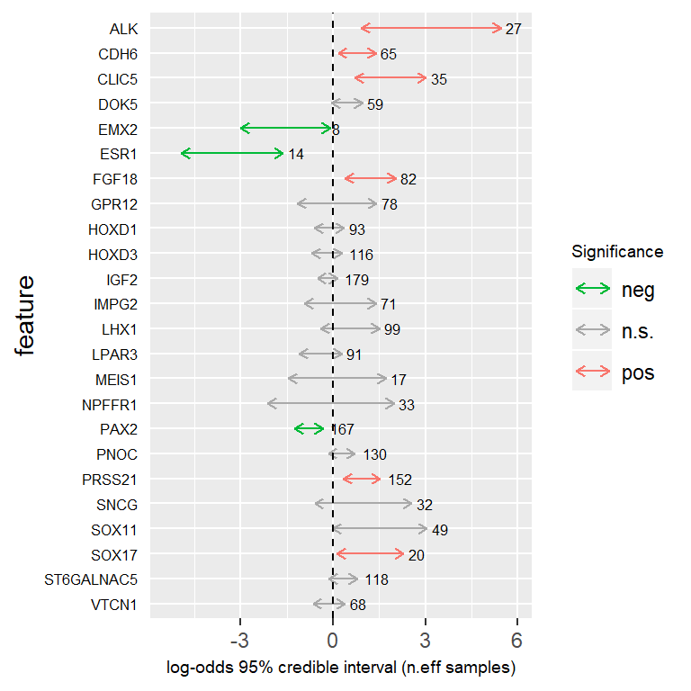

Figure 8: HOmics gene coefficients  
Credible intervals for the assessed genes obtained with HOmics.

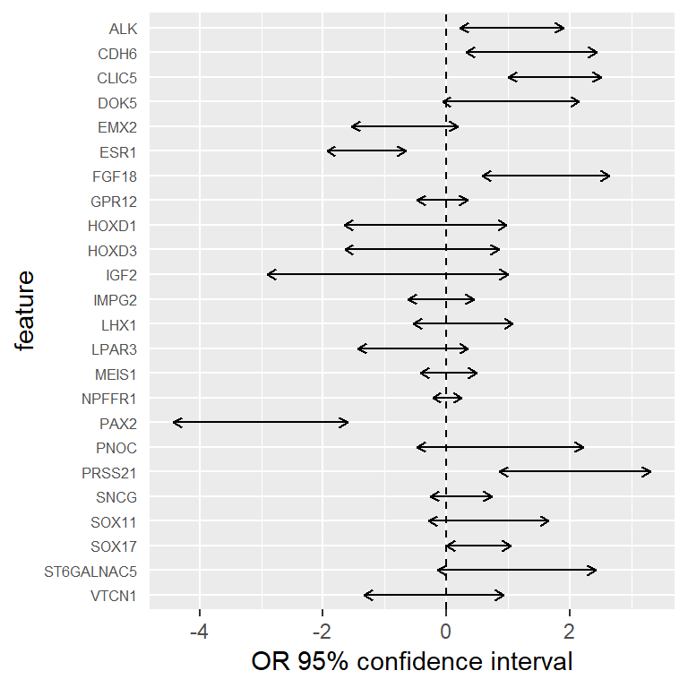

Figure 9: Limma gene coefficients  
Confidence intervals for the assessed genes obtained with limma.

```r
plot(mod.ov)
```

# 3 Integration of *omics* data

## 3.1 Example 5: Methylation beta-values integrated to gene expression

In this example, we will use GEO public data from a data superseries (GSE117931) containing methylation data (GSE117929), used in previous example, but also expression data (GSE117928) from the same set of samples. GSE117928 expression data was downloaded as an ExpressionSet using package *GEOquery* and is accessible as the data object *GSE117928* in **HOmics**.

We will integrate methylation of CpGs to the expression of the closest gene in the association with the phenotype variable, composed of 18 systemic sclerosis patients and 19 normal controls. Integration between gene expression and methylation is usually performed by correlations, as for instance, a hypermethylated site in the promoter of the gene can reduce its expression. Therefore, the prior information will be in this case the correlation between the gene and the CpGs.

We will take the same genes as in previous example and will construct a model for each of them.

First we load the data

```r
library(Biobase)

data("GSE117928", package="HOmics")

GSE117928
```

```
ExpressionSet (storageMode: lockedEnvironment)
assayData: 29373 features, 37 samples
  element names: exprs
protocolData: none
phenoData
  sampleNames: GSM3315399 GSM3315400 ... GSM3315435 (37 total)
  varLabels: title geo_accession ... race:ch1 (38 total)
  varMetadata: labelDescription
featureData
  featureNames: ILMN_1343291 ILMN_1651209 ... ILMN_3311190 (29373
    total)
  fvarLabels: ID Transcript ... GB_ACC (28 total)
  fvarMetadata: Column Description labelDescription
experimentData: use 'experimentData(object)'
Annotation: GPL14951
```

We need to extract and prepare the objects

```r
genes <- c("CCR5","CXCR4")

expression <- log2(exprs(GSE117928)+24)
beta.values <- exprs(GSE117929)

fdata.exp <- fData(GSE117928)
fdata.meth <- fData(GSE117929)

cond <- pData(GSE117928)$"diagnosis:ch1"
table(cond)
```

```
cond
 NC SSc
 19  18
```

The expression matrix is given with the microarray IDs. To transform this into a matrix with Symbols, it is easy to use dplyr functions

```r
expression.t<-as_tibble(expression)
expression.t <- left_join(fdata.exp %>% dplyr::select(ID,Symbol),
                      expression.t %>% mutate(ID = rownames(expression)),
                      by = 'ID')

expression.t <- expression.t %>%
                dplyr::select(-ID) %>%
                group_by(Symbol) %>%
                summarize_all(funs(mean))
```

Now, the construction of the hierarchical model for each gene will be done with a simple loop, where the z.matrix is constructed as a vector of correlations between the gene expression and beta-values of the CpGs in the region

```r
n <- length(genes)
n
```

```
[1] 2
```

```r
res.gene <- list()

for(i in 1:n){

  gene <- genes[i]

  gene.val <- unlist(expression.t %>% filter(Symbol==gene) %>% dplyr::select(-Symbol))

  cpgs.gene<- fdata.meth[grep(gene, fdata.meth$"UCSC_RefGene_Name"),
                         c("ID","UCSC_RefGene_Name" )]
  cpgs.val <- beta.values[cpgs.gene$ID,]

  data.matrix <- as.matrix(t(gene.val))
  rownames(data.matrix) <- gene

  z.matrix <- cor(gene.val,t(cpgs.val))
  rownames(z.matrix) <-gene

  res.gene[[i]] <- HOmics(data.matrix = data.matrix,
                          z.matrix = abs(z.matrix),
                          cond = cond)$results[[1]]
  names(res.gene)[i] <- gene
}
```

```
univariate analysis will be performed for each feature
cond is a factor, it has been converted to a numerical vector of 0s and 1s with NC as the reference level. A hierarchical logistic model will be fitted
univariate analysis will be performed for each feature
cond is a factor, it has been converted to a numerical vector of 0s and 1s with NC as the reference level. A hierarchical logistic model will be fitted
```

```r
res.gene.t <- bind_rows(res.gene)

res.gene.t
```

```
# A tibble: 2 x 9
  feature  mean `2.5%` `50%` `97.5%`  Rhat n.eff  p.pos p.neg
  <chr>   <dbl>  <dbl> <dbl>   <dbl> <dbl> <dbl>  <dbl> <dbl>
1 CCR5    -0.05  -1.04 -0.04    0.9   1.06    48 0.465  0.535
2 CXCR4   -0.95  -1.63 -0.92   -0.25  1.02    26 0.0032 0.997
```

If we compare these results to limma standard results

```r
expression.sym <- data.frame(expression.t[,-1])
rownames(expression.sym) <- expression.t$Symbol

cond <-as.factor(cond)
design<-model.matrix(~0+cond)
colnames(design) <- gsub("cond","",colnames(design))

fit<-lmFit(expression.sym,design)
contrast.matrix<-makeContrasts(SSc-NC ,levels=design)
fit2<-contrasts.fit(fit,contrast.matrix)
fite<-eBayes(fit2)
tt<-topTable(fite,coef=1,number=Inf,adjust="BH",confint = TRUE)

tt[genes,c("logFC","CI.L","CI.R","P.Value","adj.P.Val")]
```

```
            logFC       CI.L       CI.R    P.Value adj.P.Val
CCR5   0.06567442 -0.2157401  0.3470890 0.63989864 0.8556032
CXCR4 -0.81055386 -1.4351193 -0.1859884 0.01224881 0.1299548
```

We see that, in this case, although significance is the same, credible intervals are wider in the HOmics model in comparison to limma confidence intervals.